# Multi-Class_Prediction_of_Obesity_Risk

Ronald Nguyen 222200308

2024-07-25

# Brief description of all the data in the dataset

id: A unique identifier for each individual in the dataset.

Gender: The individual’s gender, indicating whether they are male or female.

Age: The age of the individual, representing their age in years.

Height: The height of the individual, typically measured in meters.

Weight: The weight of the individual, typically measured in kilograms.

family_history_with_overweight: Indicates whether there is a family history of overweight for the individual (yes/no).

FAVC: Stands for “Frequency of consuming high caloric food,” representing how often the individual consumes high-calorie foods (yes/no).

FCVC: Stands for “Frequency of consuming vegetables,” representing how often the individual consumes vegetables.

NCP: Stands for “Number of main meals,” indicating the number of main meals the individual consumes daily.

CAEC: Stands for “Consumption of food between meals,” representing the frequency of consuming food between meals.

SMOKE: Indicates whether the individual smokes or not (yes/no).

CH2O: Represents the amount of water consumption for the individual.

SCC: Stands for “Calories consumption monitoring,” indicating whether the individual monitors their calorie consumption (yes/no).

FAF: Stands for “Physical activity frequency,” representing the frequency of the individual’s physical activities.

TUE: Stands for “Time using technology devices,” indicating the amount of time the individual spends using technology devices.

CALC: Stands for “Consumption of alcohol,” representing the frequency of alcohol consumption.

MTRANS: Stands for “Mode of transportation,” indicating the mode of transportation the individual uses.

NObeyesdad: The target variable, representing the obesity risk category of the individual. It has multiple classes such as ‘Overweight_Level_II’, ‘Normal_Weight’, ‘Insufficient_Weight’, ‘Obesity_Type_III’, ‘Obesity_Type_II’, ‘Overweight_Level_I’, and ‘Obesity_Type_I’.

# Load and install libraries

```r
# Install required packages if they are not already installed
if (!require("caret")) install.packages("caret", dependencies = TRUE)
if (!require("class")) install.packages("class", dependencies = TRUE)
if (!require("dplyr")) install.packages("dplyr", dependencies = TRUE)
```

```r
if (!require("ggplot2")) install.packages("ggplot2", dependencies = TRUE)
if (!require("tidyverse")) install.packages("tidyverse", dependencies = TRUE)
if (!require("corrplot")) install.packages("corrplot", dependencies = TRUE)
if (!require("randomForest")) install.packages("randomForest", dependencies = TRUE)
if (!require("nnet")) install.packages("nnet", dependencies = TRUE)
if (!require("rpart")) install.packages("rpart", dependencies = TRUE)
# Load libraries
library(rpart)
library(nnet)
library(caret)
library(class)
library(dplyr)
library(ggplot2)
library(tidyverse)
library(corrplot)
library(randomForest)
```

# Set project parameters

```r
set.seed(42)  # set random seed for reproducible outputs

# Plotting size function
set_plot_dimensions <- function(width_choice, height_choice) {
    options(repr.plot.width=width_choice, repr.plot.height=height_choice)}
```

# Load and Exploring Data

```r
df_train <- read.csv("train.csv", row.names=1) # train data (to be split)
df_test <- read.csv("test.csv", row.names=1)  # unseen data
sub <- read.csv("sample_submission.csv")  # submission file
head(df_train)
```

```
##   Gender      Age   Height    Weight family_history_with_overweight FAVC
## 0   Male 24.44301 1.699998  81.66995                            yes  yes
## 1 Female 18.00000 1.560000  57.00000                            yes  yes
## 2 Female 18.00000 1.711460  50.16575                            yes  yes
## 3 Female 20.95274 1.710730 131.27485                            yes  yes
## 4   Male 31.64108 1.914186  93.79806                            yes  yes
## 5   Male 18.12825 1.748524  51.55259                            yes  yes
##       FCVC      NCP       CAEC SMOKE     CH2O SCC      FAF      TUE      CALC
## 0 2.000000 2.983297  Sometimes    no 2.763573  no 0.000000 0.976473 Sometimes
## 1 2.000000 3.000000 Frequently    no 2.000000  no 1.000000 1.000000        no
## 2 1.880534 1.411685  Sometimes    no 1.910378  no 0.866045 1.673584        no
## 3 3.000000 3.000000  Sometimes    no 1.674061  no 1.467863 0.780199 Sometimes
## 4 2.679664 1.971472  Sometimes    no 1.979848  no 1.967973 0.931721 Sometimes
## 5 2.919751 3.000000  Sometimes    no 2.137550  no 1.930033 1.000000 Sometimes
##                  MTRANS          NObeyesdad
## 0 Public_Transportation Overweight_Level_II
## 1            Automobile       Normal_Weight
## 2 Public_Transportation Insufficient_Weight
## 3 Public_Transportation    Obesity_Type_III
## 4 Public_Transportation Overweight_Level_II
## 5 Public_Transportation Insufficient_Weight
```

# Exploratory Data Analysis

This helps to understand what type of models are used.

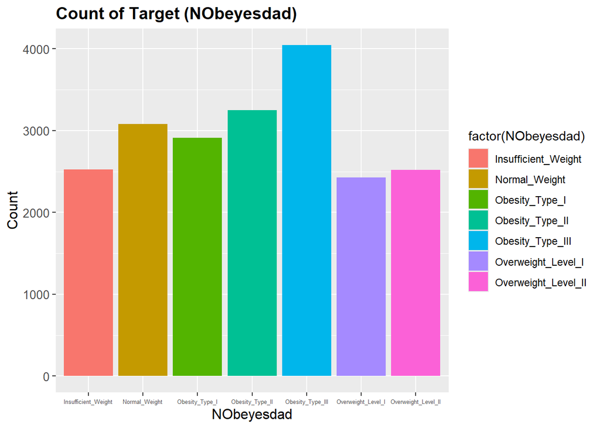

```r
# plot
ggplot(df_train, aes(x = NObeyesdad, fill = factor(NObeyesdad))) +
  geom_bar() +
  labs(title = "Count of Target (NObeyesdad)",
       x = "NObeyesdad",
       y = "Count") +
  theme(
    plot.title = element_text(size = 14, face = "bold"),
    axis.title.x = element_text(size = 12),
    axis.title.y = element_text(size = 12),
    axis.text.x = element_text(size = 5),
    axis.text.y = element_text(size = 10)
  )
```

# Correlation

Correlation between all numeric variables. If the correlation factor is positive, then it is a positive correlation and if it is negative, it is a negative correlation. If the factor is near 0, then there is almost no correlation between these variables.

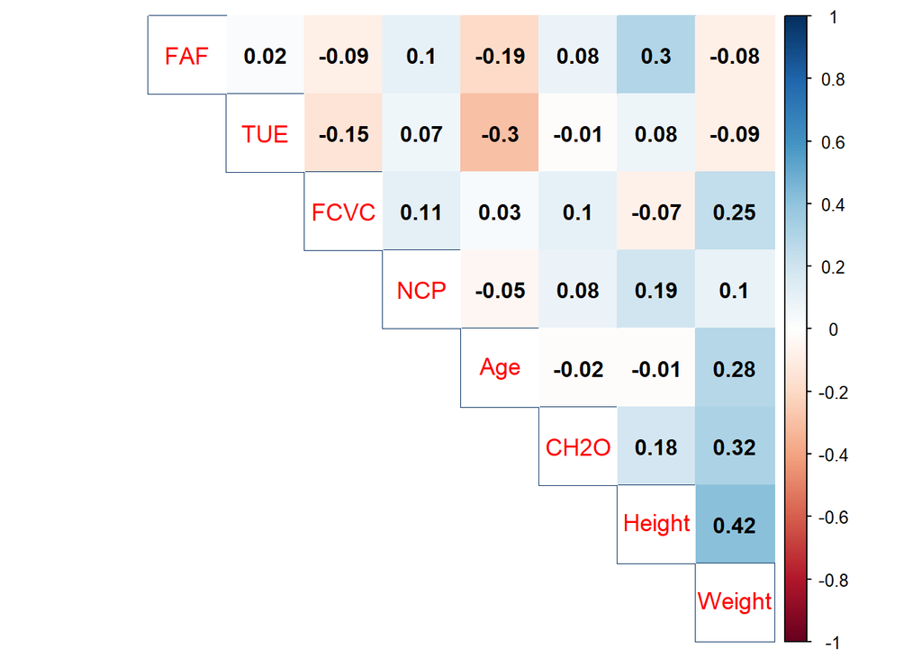

```r
set_plot_dimensions(12,12)
corrplot(df_train %>%  select_if(is.numeric) %>% cor() ,
         tl.cex = 1.1,
         method = "color", order = 'hclust', addCoef.col = 'black',type = "upper",tl.pos = 'd',
         )
```

# Feature analysis

Basic investigation to look for duplicates and null values.

```r
# duplicates across train/ test
sum(
    duplicated(rbind(df_train[, -17],df_test))
    )
```

```
## [1] 0
```

```r
# null values by column
colSums(is.na(df_train))
```

```
##                         Gender                            Age
##                              0                              0
##                         Height                         Weight
##                              0                              0
## family_history_with_overweight                           FAVC
##                              0                              0
##                           FCVC                            NCP
##                              0                              0
##                           CAEC                          SMOKE
##                              0                              0
##                           CH2O                            SCC
##                              0                              0
##                            FAF                            TUE
##                              0                              0
##                           CALC                         MTRANS
##                              0                              0
##                     NObeyesdad
##                              0
```

```r
colSums(is.na(df_test))
```

```
##                         Gender                            Age
##                              0                              0
##                         Height                         Weight
##                              0                              0
## family_history_with_overweight                           FAVC
##                              0                              0
##                           FCVC                            NCP
##                              0                              0
##                           CAEC                          SMOKE
##                              0                              0
##                           CH2O                            SCC
##                              0                              0
##                            FAF                            TUE
##                              0                              0
##                           CALC                         MTRANS
##                              0                              0
```

# Look at other variables which may need engineering for example MTRANS

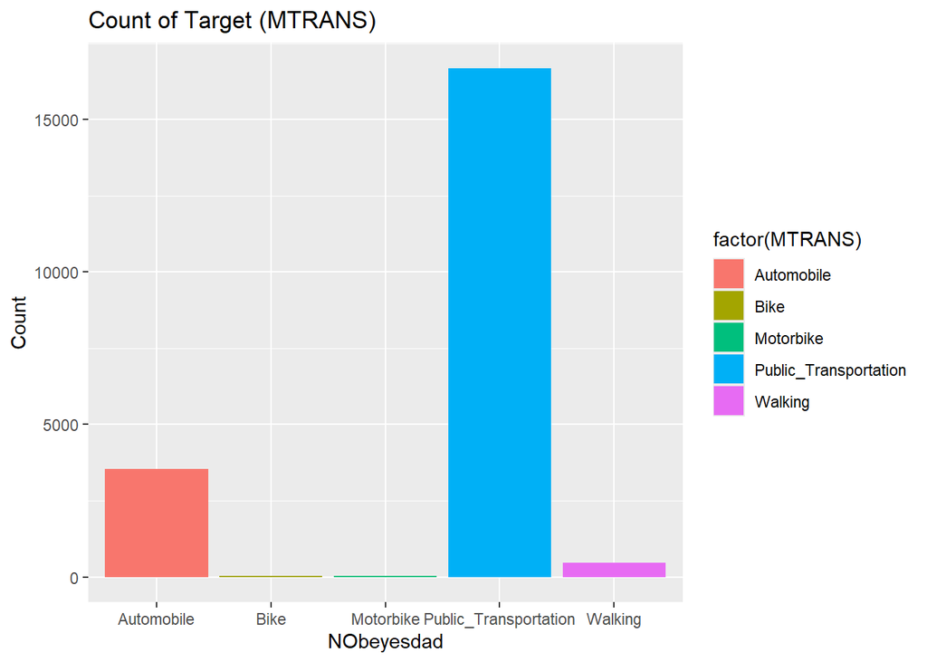

```r
set_plot_dimensions(20,7)

ggplot(df_train, aes(x = MTRANS, fill = factor(MTRANS))) +
  geom_bar() +
  labs(title = "Count of Target (MTRANS)",
       x = "NObeyesdad",
       y = "Count")
```

# Convert all character type variables to factors

```r
df_train <- df_train %>% mutate_if(is.character,as.factor)
df_test <- df_test %>% mutate_if(is.character,as.factor)

combined_df <- rbind(df_train[,-17], df_test)

# Perform one-hot encoding
# one all columns except the target
combined_df_encoded <- model.matrix(~. - 1, data = combined_df)

# Split the datasets back
train_encoded <- data.frame(
    combined_df_encoded[1:nrow(df_train), ])

# Combine
df_test <- data.frame(
    combined_df_encoded[(nrow(df_train) + 1):nrow(combined_df_encoded), ]
    )
df_train <- cbind(train_encoded ,NObeyesdad= df_train$NObeyesdad)
df_train <- df_train %>% select(-CALCAlways)
head(df_train)
```

```
##   GenderFemale GenderMale      Age   Height    Weight
## 0            0          1 24.44301 1.699998  81.66995
## 1            1          0 18.00000 1.560000  57.00000
## 2            1          0 18.00000 1.711460  50.16575
## 3            1          0 20.95274 1.710730 131.27485
## 4            0          1 31.64108 1.914186  93.79806
## 5            0          1 18.12825 1.748524  51.55259
##   family_history_with_overweightyes FAVCyes     FCVC      NCP CAECFrequently
## 0                                 1       1 2.000000 2.983297              0
## 1                                 1       1 2.000000 3.000000              1
## 2                                 1       1 1.880534 1.411685              0
## 3                                 1       1 3.000000 3.000000              0
## 4                                 1       1 2.679664 1.971472              0
## 5                                 1       1 2.919751 3.000000              0
##   CAECno CAECSometimes SMOKEyes     CH2O SCCyes      FAF      TUE CALCno
```

[output cut: 20 more lines]

# Adding BMI column adjusted by age and gender

```r
calculate_BMI <- function(weight, height, age, gender_male) {
  bmi <- weight / (height ^ 2)

  # Adjust BMI for age and gender
  if (gender_male == 1) {
    if (age < 18) {
      bmi <- bmi * 1.1
    } else if (age >= 18 & age <= 24) {
      bmi <- bmi * 1.05
    }
  } else {
    if (age < 18) {
      bmi <- bmi * 1.15
    } else if (age >= 18 & age <= 24) {
      bmi <- bmi * 1.08
    }
  }

  return(bmi)
}

df_train <- df_train %>%
  rowwise() %>%
  mutate(BMI = calculate_BMI(Weight, Height, Age, GenderMale))

df_test <- df_test %>%
  rowwise() %>%
  mutate(BMI = calculate_BMI(Weight, Height, Age, GenderMale))

str(df_train)
```

[output not shown]

[output cut: 74 more lines]

[output not shown]

# Correlation Matrix with all variables

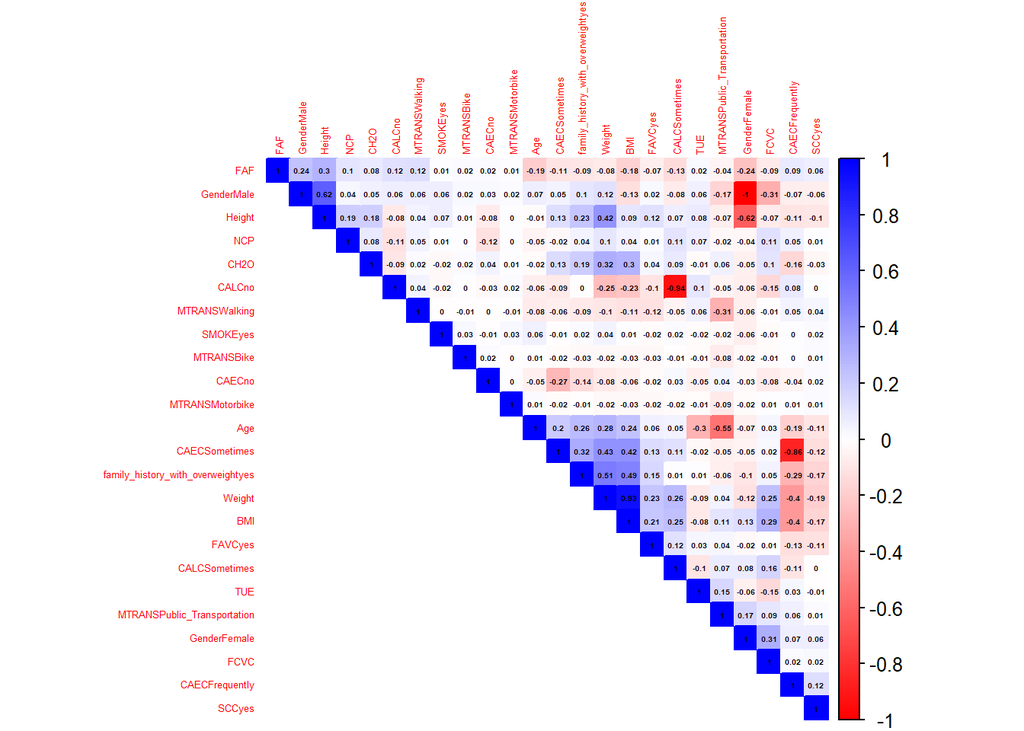

```r
# calculate the correlations in the training set
dataset_corr <- df_train %>% select_if(is.numeric) %>% cor(use = "complete.obs")

# function to plot the heatmap
plot_heatmap_correlation <- function(dataset) {
  set_plot_dimensions(10, 10)

corrplot(dataset, method = "color", order = 'hclust', addCoef.col = 'black',
           tl.cex = 0.4, number.cex = 0.3, type = "upper", tl.pos = 'lt', col = colorRampPalette(c("red", "white", "blue"))(200))


}

# plotting the heatmap
dataset_corr <- dataset_corr[, colSums(is.na(dataset_corr)) != nrow(dataset_corr)]
dataset_corr <- dataset_corr[rowSums(is.na(dataset_corr)) != ncol(dataset_corr), ]
plot_heatmap_correlation(dataset_corr)
```

# Split/Partition data

Seperate our “Train” data into training and test data (not to be confused with df_test) which is our unseen data. First the Dataset is being partitioned 70% is being used by the train_set and the rest is for the test_set. The Datasets are also splitted by X und y (X are all feature variables and y is the target variable (NObeyesdad))

```r
# Get train index
train_idx <- createDataPartition(y = df_train$NObeyesdad, p = 0.7, list = FALSE)

# Partition data into training and test sets
df_train_set <- df_train[train_idx, ]
df_test_set <- df_train[-train_idx, ]

# Split the data into X (features) and y (target)
X_train <- df_train_set %>% select(-NObeyesdad)
X_test <- df_test_set %>% select(-NObeyesdad)

y_train <- as.factor(df_train_set$NObeyesdad)
y_test <- as.factor(df_test_set$NObeyesdad)
```

# Scale

The Dataset is now scaled by centralizing (mean = 0) and scaled (standard deviation = 1) this is required for logistic regression. It can reduce training time and improve model accuracy

```r
# create the scaler function on the train data
scaler <- preProcess(x= X_train, method = c("center", "scale"))

# normalize the training date
X_train_s <- predict(scaler,X_train)
X_test_s <- predict(scaler,X_test)
```

# Random Forest

Random Forest is a Bagging ensemble (sample bootstrapping) with random feature select ioin. The error of the Random Forest model decreases as the number of trees increases.

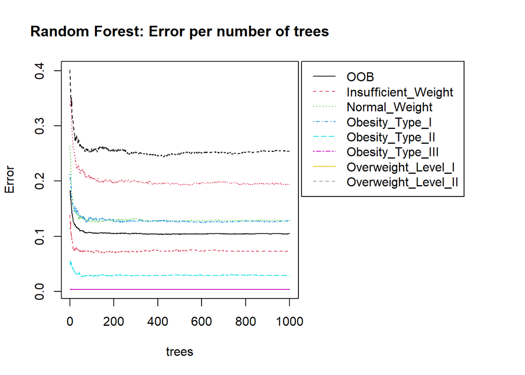

```r
rf_model <- randomForest(y_train~. , data = cbind(X_train,y_train),
                         ntree = 1000, # total number of decision trees in ensemble --> larger is more accurate but slower ro run
                         mtry= round(sqrt(ncol(df_train))), # number of features (potential for hyperparameter tuning)
                         nodesize = 20 # minimum number of terminal leaf nodes --> larger the number the smaller the tree
                        )



par(mar = c(5, 4, 4, 15) + 0.1)
plot(rf_model, main = "Random Forest: Error per number of trees")
# Place the legend outside the plot
legend("topright", inset = c(-0.7, 0), legend = colnames(rf_model$err.rate),
       col = 1:ncol(rf_model$err.rate), lty = 1:ncol(rf_model$err.rate), xpd = TRUE)
```

## Prediction

```r
y_probs <- predict(rf_model, newdata = X_test, type = "prob")
y_preds <- predict(rf_model, newdata = X_test, type = "class")
head(y_preds)
```

```
##                   1                   2                   3                   4
##    Obesity_Type_III Overweight_Level_II     Obesity_Type_II  Overweight_Level_I
##                   5                   6
##     Obesity_Type_II       Normal_Weight
## 7 Levels: Insufficient_Weight Normal_Weight Obesity_Type_I ... Overweight_Level_II
```

## Evaluation

```r
cm<- confusionMatrix(y_preds, y_test)
cm
```

```
## Confusion Matrix and Statistics
##
##                      Reference
## Prediction            Insufficient_Weight Normal_Weight Obesity_Type_I
##   Insufficient_Weight                 685            51              0
##   Normal_Weight                        64           814              2
##   Obesity_Type_I                        0             0            774
##   Obesity_Type_II                       0             0             33
##   Obesity_Type_III                      0             0              4
##   Overweight_Level_I                    5            51             12
##   Overweight_Level_II                   2             8             48
##                      Reference
## Prediction            Obesity_Type_II Obesity_Type_III Overweight_Level_I
##   Insufficient_Weight               0                0                  6
##   Normal_Weight                     0                0                 61
##   Obesity_Type_I                   18                1                 15
##   Obesity_Type_II                 947                0                  0
##   Obesity_Type_III                  1             1211                  0
##   Overweight_Level_I                0                1                567
##   Overweight_Level_II               8                0                 79
##                      Reference
## Prediction            Overweight_Level_II
##   Insufficient_Weight                   0
##   Normal_Weight                        10
##   Obesity_Type_I                       55
##   Obesity_Type_II                       7
##   Obesity_Type_III                      0
##   Overweight_Level_I                   64
##   Overweight_Level_II                 620
##
## Overall Statistics
##
##                Accuracy : 0.9026
##                  95% CI : (0.895, 0.9099)
##     No Information Rate : 0.1949
##     P-Value [Acc > NIR] : < 2.2e-16
##
##                   Kappa : 0.8858
##
##  Mcnemar's Test P-Value : NA
```

[output cut: 24 more lines]

```
## Pos Pred Value                        0.9959                    0.8100
## Neg Pred Value                        0.9996                    0.9709
## Prevalence                            0.1949                    0.1170
## Detection Rate                        0.1946                    0.0911
## Detection Prevalence                  0.1954                    0.1125
## Balanced Accuracy                     0.9987                    0.8773
##                      Class: Overweight_Level_II
## Sensitivity                             0.82011
## Specificity                             0.97348
## Pos Pred Value                          0.81046
## Neg Pred Value                          0.97509
## Prevalence                              0.12147
## Detection Rate                          0.09961
## Detection Prevalence                    0.12291
## Balanced Accuracy                       0.89679
```

```r
# calculate the feature importances
importance_data <- as.data.frame(rf_model$importance)
importance_data$Feature <- rownames(importance_data)
rownames(importance_data) <- NULL

# sort the features by importanc
importance_data <- importance_data %>%
  arrange(desc(MeanDecreaseGini))

# change the order of the levels of the features
importance_data$Feature <- factor(importance_data$Feature, levels = importance_data$Feature)

# table of the importance of the data
print(importance_data)
```

```
##    MeanDecreaseGini                           Feature
## 1       3029.785690                               BMI
## 2       2873.048750                            Weight
## 3        746.123525                               Age
## 4        705.483058                              FCVC
## 5        515.606954                            Height
## 6        446.807497                        GenderMale
## 7        402.077633                      GenderFemale
## 8        236.762842                              CH2O
## 9        234.072549                               TUE
## 10       189.551284 family_history_with_overweightyes
## 11       177.374985                               NCP
## 12       163.081646                               FAF
## 13        98.601339                    CAECFrequently
## 14        96.259597                     CALCSometimes
## 15        94.509746                     CAECSometimes
## 16        85.883641                            CALCno
## 17        67.339232                           FAVCyes
## 18        56.887586       MTRANSPublic_Transportation
## 19        27.063427                            CAECno
## 20        18.752025                            SCCyes
## 21        10.557165                     MTRANSWalking
## 22         5.840689                          SMOKEyes
## 23         1.896319                        MTRANSBike
## 24         1.275444                   MTRANSMotorbike
```

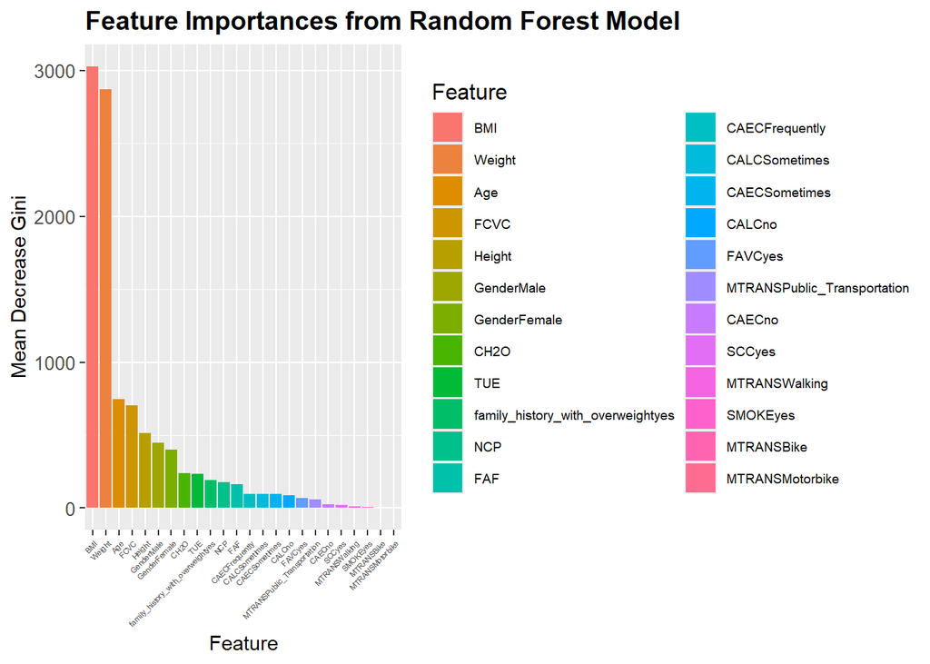

```r
ggplot(importance_data, aes(x = reorder(Feature, -MeanDecreaseGini), y = MeanDecreaseGini, fill = Feature)) +
  geom_bar(stat = "identity") +
  theme(axis.text.x = element_text(angle = 45, hjust = 1, size = 4), # Schriftgröße
        axis.text.y = element_text(size = 10),
        plot.title = element_text(size = 14, face = "bold"),
        legend.title = element_text(size = 12), # Schriftgröße der Legendentitel
        legend.text = element_text(size = 7)) + # Schriftgröße der Legendentexte
  labs(x = "Feature", y = "Mean Decrease Gini", title = "Feature Importances from Random Forest Model")
```

# Decision Tree

Plotting the decision tree

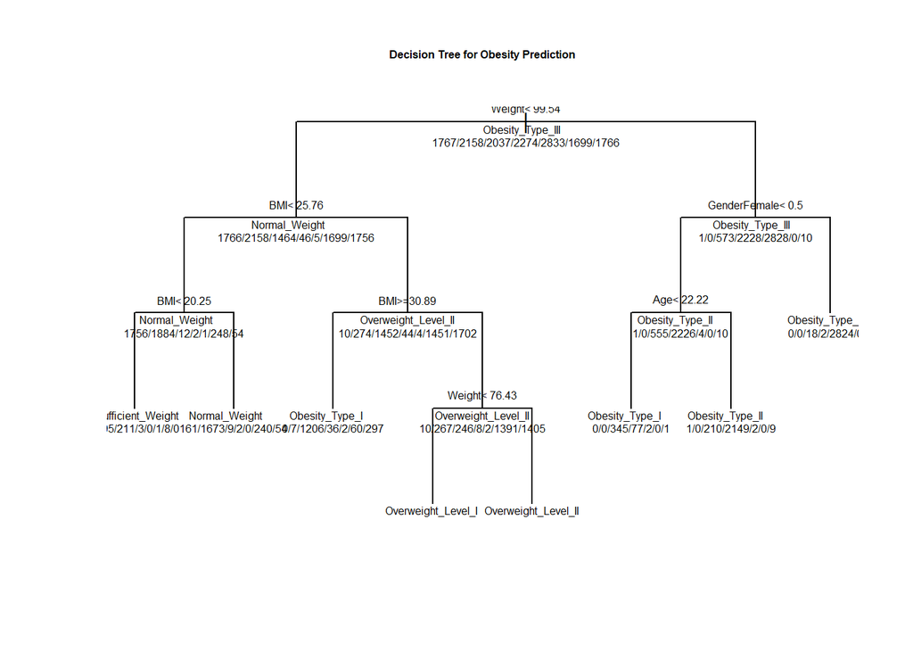

```r
# Fit the decision tree model
tree_model <- rpart(NObeyesdad ~ ., data = df_train_set, method = "class")

# Plot the decision tree
plot(tree_model, uniform = TRUE, main = "Decision Tree for Obesity Prediction", cex.main = 0.5, cex.lab = 0.01)

# Add text labels to the decision tree
text(tree_model, use.n = TRUE, all = TRUE, cex = 0.5)  # Adjust 'cex' to change text size
```

## Prediction and evaluation of the decision tree

```r
tree_pred <- predict(tree_model, df_test_set, type = "class")
tree_cm <- confusionMatrix(tree_pred, df_test_set$NObeyesdad)
print(tree_cm)
```

```
## Confusion Matrix and Statistics
##
##                      Reference
## Prediction            Insufficient_Weight Normal_Weight Obesity_Type_I
##   Insufficient_Weight                 653            84              0
##   Normal_Weight                        97           707              2
##   Obesity_Type_I                        0             1            676
##   Obesity_Type_II                       0             0             92
##   Obesity_Type_III                      0             0             10
##   Overweight_Level_I                    4           117             11
##   Overweight_Level_II                   2            15             82
##                      Reference
## Prediction            Obesity_Type_II Obesity_Type_III Overweight_Level_I
##   Insufficient_Weight               0                0                  6
##   Normal_Weight                     0                0                 88
##   Obesity_Type_I                   46                1                 25
##   Obesity_Type_II                 920                0                  0
##   Obesity_Type_III                  1             1211                  0
##   Overweight_Level_I                0                1                420
##   Overweight_Level_II               7                0                189
##                      Reference
## Prediction            Overweight_Level_II
##   Insufficient_Weight                   0
##   Normal_Weight                        28
##   Obesity_Type_I                      134
##   Obesity_Type_II                       7
##   Obesity_Type_III                      1
##   Overweight_Level_I                   53
##   Overweight_Level_II                 533
##
## Overall Statistics
##
##                Accuracy : 0.8226
##                  95% CI : (0.8129, 0.832)
##     No Information Rate : 0.1949
##     P-Value [Acc > NIR] : < 2.2e-16
##
##                   Kappa : 0.7918
##
##  Mcnemar's Test P-Value : NA
```

[output cut: 24 more lines]

```
## Pos Pred Value                        0.9902                   0.69307
## Neg Pred Value                        0.9996                   0.94518
## Prevalence                            0.1949                   0.11697
## Detection Rate                        0.1946                   0.06748
## Detection Prevalence                  0.1965                   0.09737
## Balanced Accuracy                     0.9980                   0.77154
##                      Class: Overweight_Level_II
## Sensitivity                             0.70503
## Specificity                             0.94605
## Pos Pred Value                          0.64372
## Neg Pred Value                          0.95867
## Prevalence                              0.12147
## Detection Rate                          0.08564
## Detection Prevalence                    0.13303
## Balanced Accuracy                       0.82554
```

# logistic regression model

```r
# Fit the logistic regression model
glm_model <- multinom(NObeyesdad ~ ., data = df_train_set)
```

## Predict and Evaluate

```r
# Predict on the test set
glm_pred <- predict(glm_model, newdata = df_test_set)

# Evaluate the model
glm_cm <- confusionMatrix(glm_pred, df_test_set$NObeyesdad)
print(glm_cm)
```

```
## Confusion Matrix and Statistics
##
##                      Reference
## Prediction            Insufficient_Weight Normal_Weight Obesity_Type_I
##   Insufficient_Weight                 691           107              0
##   Normal_Weight                        61           740              2
##   Obesity_Type_I                        0             0            724
##   Obesity_Type_II                       0             0             51
##   Obesity_Type_III                      0             0             10
##   Overweight_Level_I                    2            63             27
##   Overweight_Level_II                   2            14             59
##                      Reference
## Prediction            Obesity_Type_II Obesity_Type_III Overweight_Level_I
##   Insufficient_Weight               0                0                  7
##   Normal_Weight                     0                0                105
##   Obesity_Type_I                   38                4                 27
##   Obesity_Type_II                 925                0                  0
##   Obesity_Type_III                  0             1208                  0
##   Overweight_Level_I                0                1                490
##   Overweight_Level_II              11                0                 99
##                      Reference
## Prediction            Overweight_Level_II
##   Insufficient_Weight                   0
##   Normal_Weight                        23
##   Obesity_Type_I                      133
##   Obesity_Type_II                       8
##   Obesity_Type_III                      2
##   Overweight_Level_I                  141
##   Overweight_Level_II                 449
##
## Overall Statistics
##
##                Accuracy : 0.8398
##                  95% CI : (0.8305, 0.8488)
##     No Information Rate : 0.1949
##     P-Value [Acc > NIR] : < 2.2e-16
##
##                   Kappa : 0.8121
##
##  Mcnemar's Test P-Value : NA
```

[output cut: 24 more lines]

```
## Pos Pred Value                        0.9902                   0.67680
## Neg Pred Value                        0.9990                   0.95673
## Prevalence                            0.1949                   0.11697
## Detection Rate                        0.1941                   0.07873
## Detection Prevalence                  0.1960                   0.11632
## Balanced Accuracy                     0.9967                   0.81525
##                      Class: Overweight_Level_II
## Sensitivity                             0.59392
## Specificity                             0.96617
## Pos Pred Value                          0.70820
## Neg Pred Value                          0.94508
## Prevalence                              0.12147
## Detection Rate                          0.07214
## Detection Prevalence                    0.10186
## Balanced Accuracy                       0.78004
```

# Submit random forest model

This submission got a public score of 0.88908.

```r
sub_preds <- predict(rf_model,as.matrix(df_test))
head(sub_preds)
```

```
##                   1                   2                   3                   4
##     Obesity_Type_II  Overweight_Level_I    Obesity_Type_III      Obesity_Type_I
##                   5                   6
##    Obesity_Type_III Insufficient_Weight
## 7 Levels: Insufficient_Weight Normal_Weight Obesity_Type_I ... Overweight_Level_II
```

```r
# create a mapping vector
mapping_vector <- setNames(levels(y_train), 1:7)

# Converting numbers back to text
sub$NObeyesdad<- mapping_vector[sub_preds]

head(sub)
```

```
##      id          NObeyesdad
## 1 20758     Obesity_Type_II
## 2 20759  Overweight_Level_I
## 3 20760    Obesity_Type_III
## 4 20761      Obesity_Type_I
## 5 20762    Obesity_Type_III
## 6 20763 Insufficient_Weight
```

```r
write.csv(sub, "submission_rf.csv", row.names = FALSE)
```

# Improved random tree forest through feature importance and correlations

```r
correlation_matrix <- cor(df_train %>% select_if(is.numeric), use = "complete.obs")

importance_data <- as.data.frame(rf_model$importance)
importance_data$Feature <- rownames(importance_data)
rownames(importance_data) <- NULL

importance_data <- importance_data %>%
  arrange(desc(MeanDecreaseGini))

# delete high correlated and less important features
high_correlation_threshold <- 0.9
low_importance_threshold <- quantile(importance_data$MeanDecreaseGini, 0.2)

highly_correlated_features <- findCorrelation(correlation_matrix, cutoff = high_correlation_threshold)
low_importance_features <- importance_data$Feature[importance_data$MeanDecreaseGini < low_importance_threshold]

# delete specific features
features_to_remove <- union(names(highly_correlated_features), low_importance_features)
df_train_reduced <- df_train_set %>% select(-one_of(features_to_remove))
df_test_reduced <- df_test_set %>% select(-one_of(features_to_remove))

X_train_reduced <- df_train_reduced %>% select(-NObeyesdad)
X_test_reduced <- df_test_reduced %>% select(-NObeyesdad)

y_train_reduced <- as.factor(df_train_reduced$NObeyesdad)
y_test_reduced <- as.factor(df_test_reduced$NObeyesdad)

# training of the reduced random forest model
rf_model_reduced <- randomForest(y_train_reduced ~ ., data = cbind(X_train_reduced, y_train_reduced),
                                 ntree = 1000, mtry = round(sqrt(ncol(df_train_reduced))))

# predictions on the test set
y_probs_reduced <- predict(rf_model_reduced, newdata = X_test_reduced, type = "prob")
y_preds_reduced <- predict(rf_model_reduced, newdata = X_test_reduced, type = "class")

# evaluation
cm_reduced <- confusionMatrix(y_preds_reduced, y_test_reduced)
print(cm_reduced)
```

```
## Confusion Matrix and Statistics
##
##                      Reference
## Prediction            Insufficient_Weight Normal_Weight Obesity_Type_I
##   Insufficient_Weight                 697            52              0
##   Normal_Weight                        53           816              1
##   Obesity_Type_I                        0             0            776
##   Obesity_Type_II                       0             0             31
##   Obesity_Type_III                      0             0              4
##   Overweight_Level_I                    4            48             18
##   Overweight_Level_II                   2             8             43
##                      Reference
## Prediction            Obesity_Type_II Obesity_Type_III Overweight_Level_I
##   Insufficient_Weight               0                0                  6
##   Normal_Weight                     0                0                 61
##   Obesity_Type_I                   18                1                 15
##   Obesity_Type_II                 947                0                  0
##   Obesity_Type_III                  1             1211                  0
##   Overweight_Level_I                0                1                574
##   Overweight_Level_II               8                0                 72
##                      Reference
## Prediction            Overweight_Level_II
##   Insufficient_Weight                   0
##   Normal_Weight                         9
##   Obesity_Type_I                       52
##   Obesity_Type_II                       7
##   Obesity_Type_III                      0
##   Overweight_Level_I                   69
##   Overweight_Level_II                 619
##
## Overall Statistics
##
##                Accuracy : 0.9062
##                  95% CI : (0.8987, 0.9133)
##     No Information Rate : 0.1949
##     P-Value [Acc > NIR] : < 2.2e-16
##
##                   Kappa : 0.8899
##
##  Mcnemar's Test P-Value : NA
```

[output cut: 24 more lines]

```
## Pos Pred Value                        0.9959                   0.80392
## Neg Pred Value                        0.9996                   0.97205
## Prevalence                            0.1949                   0.11697
## Detection Rate                        0.1946                   0.09222
## Detection Prevalence                  0.1954                   0.11472
## Balanced Accuracy                     0.9987                   0.88149
##                      Class: Overweight_Level_II
## Sensitivity                             0.81878
## Specificity                             0.97568
## Pos Pred Value                          0.82314
## Neg Pred Value                          0.97496
## Prevalence                              0.12147
## Detection Rate                          0.09945
## Detection Prevalence                    0.12082
## Balanced Accuracy                       0.89723
```

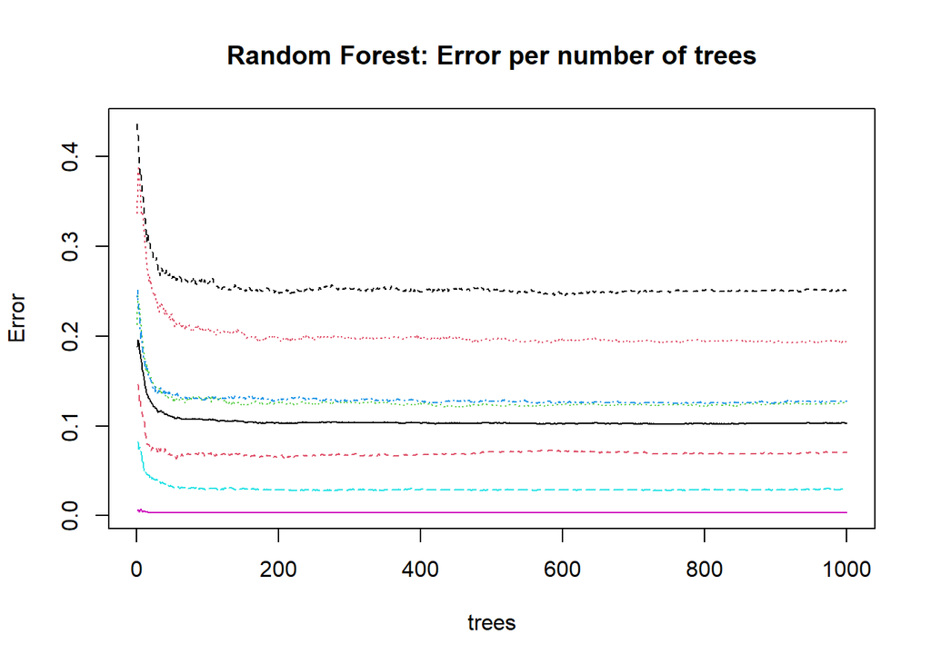

```r
# convert the confusion matrix into a data frame
cm_df <- as.data.frame(cm_reduced$table)


# Plot the error
plot(rf_model_reduced, main = "Random Forest: Error per number of trees")
```

## Evaluation

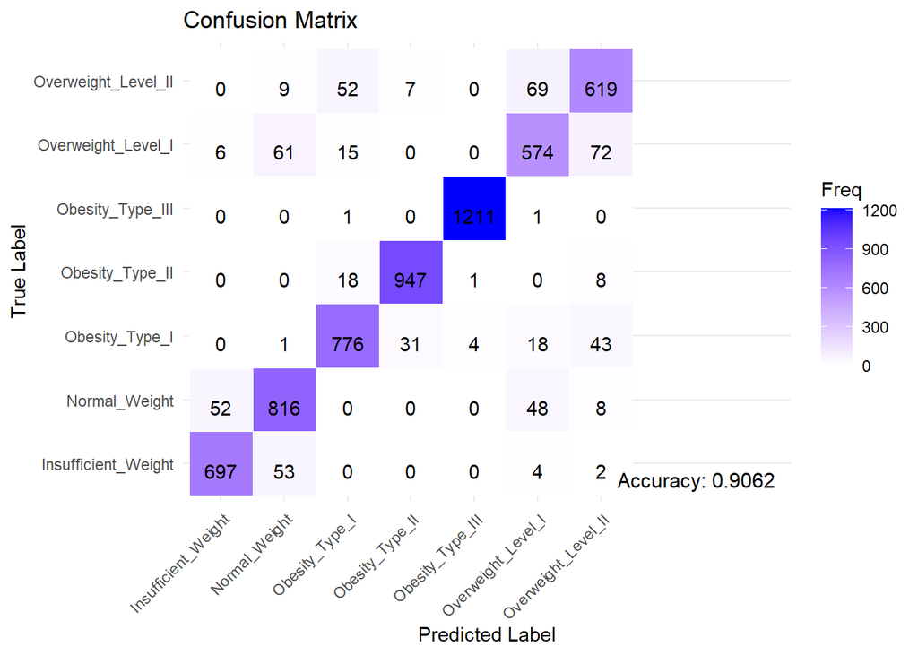

```r
# calculate the accuracy
accuracy <- sum(diag(cm_reduced$table)) / sum(cm_reduced$table)
accuracy_label <- paste0("Accuracy: ", round(accuracy * 100, 2), "%")
# create the heatmpa
ggplot(data = cm_df, aes(x = Prediction, y = Reference)) +
  geom_tile(aes(fill = Freq), color = "white") +
  scale_fill_gradient(low = "white", high = "blue") +
  geom_text(aes(label = Freq), vjust = 1) +
  labs(title = "Confusion Matrix", x = "Predicted Label", y = "True Label") +
  theme_minimal() +
  theme(axis.text.x = element_text(angle = 45, hjust = 1)) +
  annotate("text", x = 10, y = 1, label = paste0("Accuracy: ", round(accuracy, 4)), vjust = 1.5, hjust = 1.1, size = 4, color = "black", Position = "bottom")
```

# Submit improved random forest model

This submission got a public score of 0.89884.

```r
sub_preds <- predict(rf_model_reduced,as.matrix(df_test))
head(sub_preds)
```

```
##                   1                   2                   3                   4
##     Obesity_Type_II  Overweight_Level_I    Obesity_Type_III      Obesity_Type_I
##                   5                   6
##    Obesity_Type_III Insufficient_Weight
## 7 Levels: Insufficient_Weight Normal_Weight Obesity_Type_I ... Overweight_Level_II
```

```r
# create a mapping vector
mapping_vector <- setNames(levels(y_test), 1:7)

# Converting numbers back to text
sub$NObeyesdad<- mapping_vector[sub_preds]

head(sub)
```

```
##      id          NObeyesdad
## 1 20758     Obesity_Type_II
## 2 20759  Overweight_Level_I
## 3 20760    Obesity_Type_III
## 4 20761      Obesity_Type_I
## 5 20762    Obesity_Type_III
## 6 20763 Insufficient_Weight
```

```r
write.csv(sub, "submission_improved_rf.csv", row.names = FALSE)
```

# comparison between all models

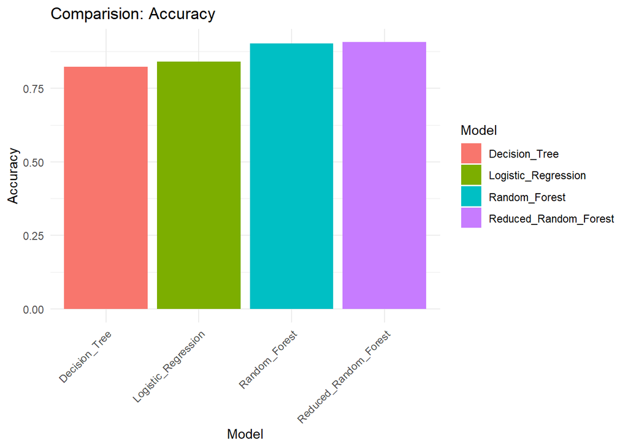

```r
results <- list()
results$Reduced_Random_Forest <- cm_reduced$overall['Accuracy']
results$Logistic_Regression <- glm_cm$overall['Accuracy']
results$Decision_Tree <- tree_cm$overall['Accuracy']
results$Random_Forest <- cm$overall['Accuracy']

results_df <- data.frame(Model = names(results),
                         Accuracy = unlist(results))


ggplot(results_df, aes(x = Model, y = Accuracy, fill = Model)) +
  geom_bar(stat = "identity") +
  theme_minimal() +
  labs(title = "Comparision: Accuracy",
       x = "Model",
       y = "Accuracy") +
  theme(axis.text.x = element_text(angle = 45, hjust = 1))
```